# Mini-cursos: Introdução ao R - Mapeamento Genético - Sequenciamento de RNA e Expressão Diferencial

Para todas as práticas é necessário fazer o download da pasta "Arquivos_Workshop-master" no menu localizado no canto direito superior desta página.

No menu você também encontrará as apresentações teóricas e outras informações.

## Mapeamento genético {prática}

28 Jul 2015

Neste arquivo serão apresentados os passos realizados para o mapeamento genético de uma população $F_{2}$ de *Mimulus*. O mapa inicial já foi publicado por Fishman *et al.* (2001) e será utilizado como um direcionamento, quando necessário. Novos marcadores serão incluídos, com a finalidade de melhorar este mapa genético.

### 1º passo

Instalação dos pacotes dplyr, OneMap e ggplot2.

```r
install.packages("onemap") # instalando o pacote
```

```r
library(dplyr)   # para carregar o pacote
library(magrittr)
library(onemap)
```

```r
library(ggplot2)
```

Leitura dos dados de *Mimulus*.

```r
mimulus <- read.mapmaker(file = "mimulus.txt") # leitura de dados

mimulus              # informação do conjunto de dados
```

Nestes novos dados, serão analisados 418 marcadores em um conjunto de 287 indivíduos da geração $F_{2}$. Dentre esses marcadores, 213 são codominantes e 205 são dominantes (113 + 92).

### 2º passo

Estabelecimento da frequência de recombinação entre todos os pares de marcadores.

```r
freqrecomb <- rf.2pts(mimulus, LOD = 3, max.rf = 0.50) # teste de dois pontos
```

### 3º passo

No artigo de Fishman *et al.* (2001), foi utilizado um LOD *score* de $6.0$ e a distância máxima de $37$ cM. Como neste novo mapa estão incluídos mais marcadores, será realizada o cálculo de qual LOD é mais adequado para essa situação.

```r
marcadores <- make.seq(freqrecomb, "all")  # fazendo uma sequência de todos os marcadores

ntestes<- choose(418, 2)
dist <- qchisq(1-(0.05/ntestes),1)
LOD <- 0.2172 * dist
LOD
```

```
## [1] 5.43
```

Considerando a combinação $marcador_{i}-marcador_{i'}$, podem ser realizados 87153 testes. Como o valor do LOD *score* possui uma correlação com o número de marcadores analisados, esse valor foi de 5.4297. A partir deste valor, optou-se em manter o LOD *score* utilizado no artigo de referência (LOD = 6). Assim, o passo seguinte constituiu em estabelecer os grupos de ligação, a partir da função **group()**.

Inicialmente, foram feitos vários testes utilizando-se diferentes frequências de recombinação máxima e posteriormente optou-se em utilizar um max.rf de 0.4.

```r
grupos <- group(marcadores, LOD=6, max.rf=0.4)  # atribuindo marcadores em GL

grupos          # mostra quais foram os grupos que se formaram
```

```
##   This is an object of class 'group'
##   It was generated from the object "marcadores"
##
##   Criteria used to assign markers to groups:
##     LOD = 6 , Maximum recombination fraction = 0.4
##
##   No. markers:            418
##   No. groups:             10
##   No. linked markers:     411
##   No. unlinked markers:   7
##
##   Printing groups:
##   Group 1 : 82 markers
##     AA461 AA341 AA173C AA137 BA449 BA416 BA387 BA374 BA214 BA196 BA153 BA129 BB216 BB124 CA267 CA174 CA150 CA75 BD371 BD340 BD270 BD251 BD100 CA389C AAT225 AAT267 AAT265 BC542 BC374 BC80 BC526C BC194C CC447 CC320 CC138 CC93 CC61 CC53 AAT333 AP3 MgSTS17 MgSTS16 MgSTS18 MgSTS20 MgSTS19 MgSTS24 MgST…
##
##   Group 2 : 22 markers
##     AA420 BA301 BA172 BA125 CA279 CA228 CB280 BD175 BD99 BC167 BC126 CC132 CC130 CC385C MgSTS316 MgSTS49 MgSTS106 MgSTS56 MgSTS457 MgSTS513 MgSTS589 MgSTS565
##
##   Group 3 : 87 markers
##     AA404 AA361 AA280 AA100 BA497 BA384 BA220 BA75 BB281 BB259 BB190 BB122 BB119 BB102 CA289 CA238 CA220 CA198 CA131 CA96 CB309 CB246 CB187 CB173 CB166 CB162 CB156 BD433 BD429 BD292 BD286 BD263 BD209 BD170 BD68 AA153C CA258C BB103C AAT261 AAT278 AAT374 AAT372 AG19 BC498 BC379 BC334 BC131 BC70 BC5…
##
##   Group 4 : 40 markers
##     AA384 AA166C AA66 BA210 BA113 BB208 CA497 CA415 CA399 CA384 CA297 CA233 CB329 CB257 BD411 BD243 BD239 BD130 BD115 AA346C AA374C BA279C CA183C AAT367 BC512 BC321 BC216 BC192 CC531 CC270 MgSTS132 MgSTS228 MgSTS234 MgSTS455 MgSTS262 MgSTS362 MgSTS492 MgSTS347 MgSTS477 MgSTS542B
##
##   Group 5 : 21 markers
##     AA378 AA268 AA163 BA69 BB210 BB186 CA264 CA226 CB230 BD316C BD173 AA118C AA454C BC506 CC342 CC124 MgSTS40 MgSTS245 MgSTS282A MgSTS255 MgSTS586
##
##   Group 6 : 51 markers
##     AA371C AA311 AA277 AA270 AA158 BA222 BA117 CA283 CA152C CB333 BD179 BD169 BD55 AAT230 AAT300 BC392 BC243 BC125 CC457 CC381 CC262 CC126 CC171C MgSTS21 MgSTS25 MgSTS22 MgSTS28 MgSTS105 MgSTS120 MgSTS58 MgSTS229 MgSTS323 MgSTS508 MgSTS529 MgSTS480 MgSTS426 MgSTS453 MgSTS456 MgSTS430 MgSTS314 MgS…
##
##   Group 7 : 32 markers
##     AA246 BA372 BA314 BA158 BB167 CA305 CA210 CA122 CB272 BD189C AAT217 AAT39 AAT211 AAT296 CYCB AAT242 CC450 CC359 CC338C MgSTS59 MgSTS69 MgSTS31 MgSTS76 MgSTS330 MgSTS381 MgSTS571 MgSTS590 MgSTS537 MgSTS538 MgSTS563 MgSTS504C MgSTS621
##
##   Group 8 : 26 markers
##     AA167 AA95 BA445 BA400 BA311 BB218 BB176 CA261 CA217 CA196 CA167 CB115 BA396C AAT222 BC108 BC83 CC540 CC402 LFY MgSTS468 MgSTS638 MgSTS536 MgSTS558 MgSTS611 MgSTS600 MgSTS470
##
##   Group 9 : 29 markers
##     BA394 BA175 BB182 CA378 CA140 CB216 BD242 BD143 AA296C BA245C AAT233 AAT272 AAT308 AAT364 BC546 BC478 BC388 BC376 BC330 BC266 BC219 CC149 CC114 MgSTS36 MgSTS437 MgSTS113 MgSTS282B MgSTS548 MgSTS438
##
##   Group 10 : 21 markers
##     BA334 BA145 BB198 CA315 CB172 CB126 CB55 CB263C AAT240 BC199 CC150 MgSTS55 MgSTS45 MgSTS11 MgSTS68 MgSTS326 MgSTS419 MgSTS577 MgSTS104 MgSTS622 MgSTS599
##
##   Unlinked markers: 7  markers
##     AA208 BB327 BB279 CA392 BC135 CC371 MgSTS23
```

```r
set.map.fun(type="kosambi") # estabelecendo uma distância para o mapa
```

Com essa análise, foram obtidos 10 grupos de ligação, sendo que sete marcadores ficaram não ligados a nenhum grupo (AA208, BB327, BB279, CA392, BC135, CC371, MgSTS23).

### 4º passo

Os passos seguintes são analisar cada grupo de ligação isoladamente, detectar falsos positivos (usando o gráfico heatmap), verificar o melhor ordenamento dos marcadores dentro de cada grupo.

Dentre os diversos critérios de ordenação disponíveis na literatura, os mais utilizados são: seriação (*seriation* - SER), delineação rápida em cadeia (*Rapid Chain Delineation* - RCD), contagem de recombinação e ordenação (*Recombination Counting and Ordering* - RECORD) e crescimento unidirecional (*Unidirectional Growth* - UG). Para uma visualização inicial do ordenamento dos marcadores no grupo de ligação, foi utilizado o critério RCD.

O algoritmo inicialmente utilizado neste trabalho foi o RDC, o qual considera a matriz de recombinações de todos os pares de marcas, porém não necessita que os marcadores já estejam separados por grupos de ligação. Inicia-se com o par de marcas com menor r e adiciona-se uma a uma as demais marcas com menores r nas extremidades da cadeia. O processo é encerrado quando não restarem mais marcas ou quando as restantes não estiverem significativamente ligadas a nenhuma outra. A principal desvantagem neste método é não assegurar a melhor ordenação. No entanto ele foi utilizado por ser rápido computacionalmente e para se obter uma idéia geral do posicionamento dos marcadores dentro de cada grupo.

No entanto, para o ordenamento final dos marcadores foi utilizado a função **order.seq()**. Esta função utiliza o comando **compare** (comparação de todas as ordens possíveis) para criar um mapa inicial apenas com um conjunto pequeno de marcadores em cada grupo (subset utilizado de 5 marcadores). Seguidamente o restante dos marcadores são posicionados utilizando o comando **try.seq()**.

Este comando **try.seq()** acrescenta $m'$ marcadores sequencialmente em todos os intervalos de uma subordem inicial, testando qual a posição mais provável de cada um deles. A subordem inicial pode ser obtida por busca exaustiva (**compare**), comparando as $m'!/2$ ordens possíveis. Assim, para cada uma dessas subordens é construído um mapa e calculada a verossimilhança por cadeia de Markov oculta. O sub-mapa com maior verossimilhança será considerado o correto. Posteriormente escolhe-se um marcador não mapeado (codominantes antes de dominantes e marcadores com menores níveis de dados perdidos), que poderá se posicionar em qualquer dos intervalos entre os marcadores ou nas extremidades ($m'+1$ posições possíveis). Para cada uma posição o mapa é reconstruído, reestimadas as frações de recombinação e calculada a verossimilhança nova. A ordem que apresentar maior verossimilhança é considerada a ordem correta e o marcador posicionado neste local. Finalmente, os marcadores são posicionados e os que possuem mais de uma posição possível são alocados na melhor posição utilizando a função **make.seq()**, com o comando **forced**.

Uma verificação final da ordem será realizada utilizando-se o algoritmo RIPPLE.

O nome de cada grupo de ligação neste trabalho será estabelecido seguindo a presença dos marcadores nos grupos de ligação do mapa de referência. Com o proposto didático, apenas alguns grupos de ligação serão abordados e o mapa final apresentado.

**Grupo 2**

```r
LG2 <- make.seq(grupos, 2)   # trabalhando com o grupo de ligação 2
LG2
```

Neste grupo de ligação, foram agrupados 22 marcadores, sendo 12 marcadores coincidentes com os marcadores do LG2 do mapa de referência e 10 novos marcadores.

```r
LG2.ord <- order.seq(input.seq=LG2,
                        n.init = 5,
                        subset.search = "twopt",
                        twopt.alg = "rcd",
                        THRES = 3,
                        draw.try = FALSE,
                        wait = 1,
                        touchdown=TRUE)
LG2.ord

LG2.new.fin <- make.seq(LG2.ord, "force")
LG2.new.fin
```

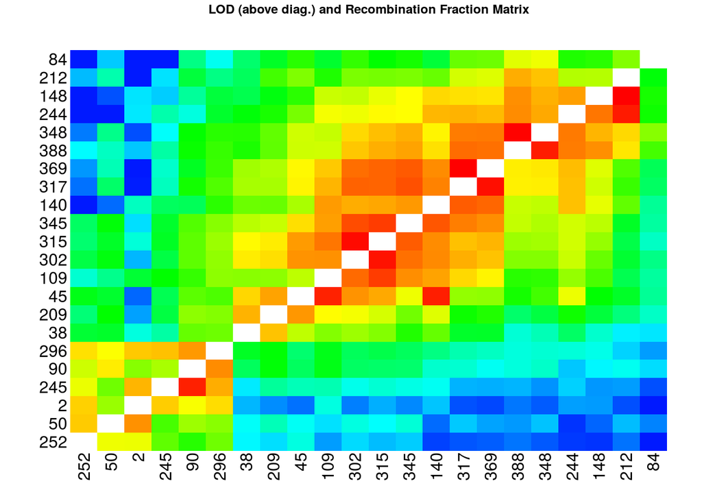

```r
rf.graph.table(LG2.new.fin, inter=FALSE)
```

Observando o gráfico do *heatmap*, evidenciou-se que o grupo apresentou uma boa ordenação. Esta evidência foi confirmada também na ordenação local, pela função **ripple.seq**.

```r
ripple.seq(LG2.new.fin, ws=5, LOD=3)
```

[output not shown]

**Segundo grupo maior**

```r
maior2 <- make.seq(grupos, 3) # trabalhando com o grupo de ligação 3
maior2
```

Neste grupo de ligação, foram agrupados 87 marcadores, sendo 12 marcadores coincidentes com os marcadores do LG3, 9 marcadores coincidentes com os do LG7 e 15 marcadores coincidentes com os do LG10 do mapa original. Posteriormente, os marcadores serão ordenados dentro deste grupo de ligação por um critério de ordenação previamente selecionado.

```r
maior2.ord <- order.seq(input.seq=maior2,
                        n.init = 5,
                        subset.search = "twopt",
                        twopt.alg = "rcd",
                        THRES = 3,
                        draw.try = FALSE,
                        wait = 1,
                        touchdown=TRUE)
maior2.ord

maior2.fin <- make.seq(maior2.ord, "force")
maior2.fin
```

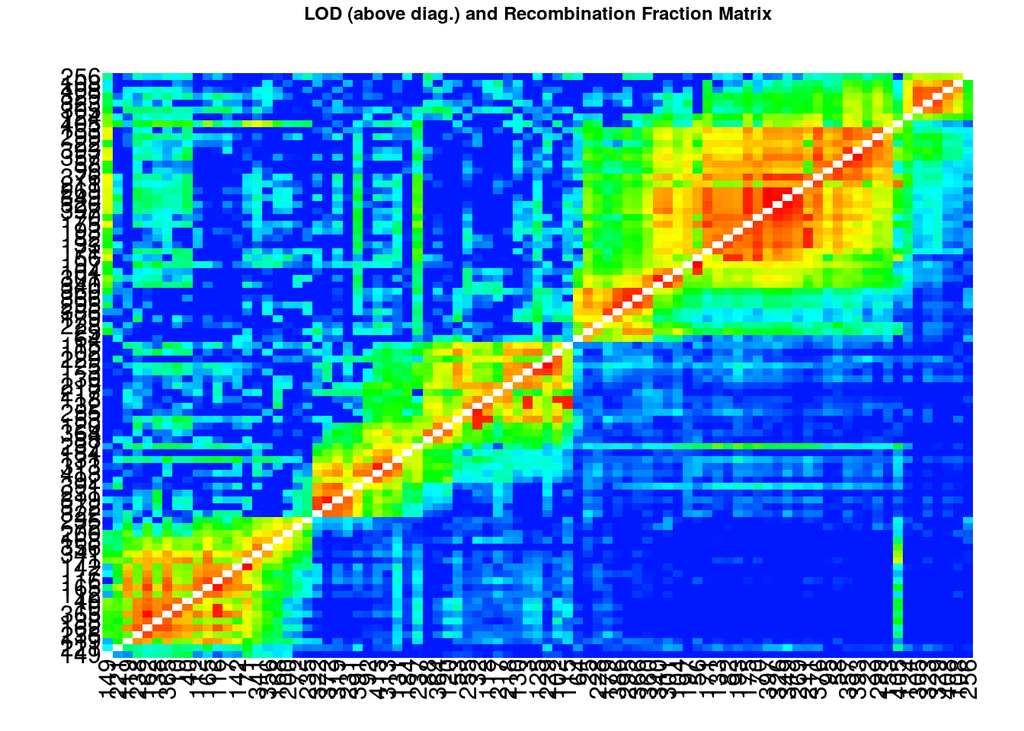

```r
rf.graph.table(maior2.fin, inter=FALSE)
```

Subdividindo o segundo maior grupo de ligação:

```r
maior2seq1 <- make.seq(freqrecomb, c(149, 221, 119, 238, 162, 138, 365, 10, 40, 112, 165,
                                  116, 7, 142, 71, 341, 356, 168, 200, 72, 235 ))
maior2seq2 <- make.seq(freqrecomb, c(322, 372, 319, 231, 391, 92, 413, 313, 131, 184, 237,
                                  88, 364, 120, 53, 255, 32, 118, 217, 218, 130, 3, 125,
                                  229, 102, 115))
maior2seq3 <- make.seq(freqrecomb, c(64, 25, 228, 179, 386, 295, 366, 360, 340, 301, 104, 197,
                                  56, 171, 133, 82, 193, 175, 70, 397, 326, 349, 269, 211,
                                  376, 95, 58, 357, 393, 22, 299, 153, 405, 124, 305, 323,
                                  329, 408, 108, 256))
```

**Grupo 10**

Agora trabalhando com a terceira sequência gerada, a qual corresponde ao LG10 do mapa de referência.

```r
LG10.ord <- order.seq(input.seq=maior2seq3,
                        n.init = 5,
                        subset.search = "twopt",
                        twopt.alg = "rcd",
                        THRES = 3,
                        draw.try = FALSE,
                        wait = 1,
                        touchdown=TRUE)
LG10.ord

LG10.new <- make.seq(LG10.ord, "force")
LG10.new
```

Neste grupo de ligação, foram agrupados 40 marcadores, sendo 15 marcadores coincidentes com os marcadores do LG10 do mapa de referência e 25 novos marcadores.

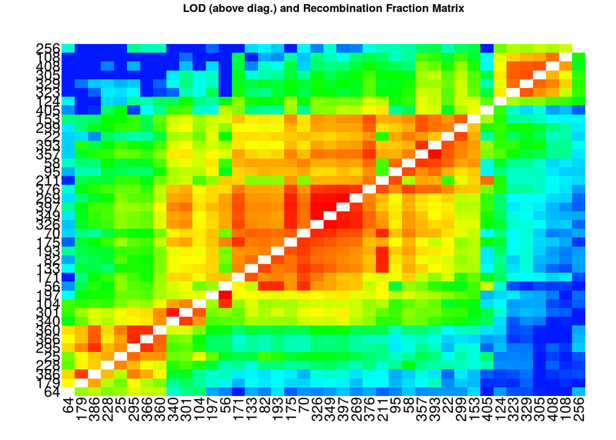

```r
rf.graph.table(LG10.new, inter=FALSE)
```

Observando o *heatmap* inicial, houve problemas de ordenação dos marcadores. Desta forma, diversos testes foram feitos.

```r
LG10.test <- drop.marker(LG10.new, c(211, 405))
LG10.test <- map(LG10.test)

LG10.new.ord <- try.seq(LG10.test, 211, draw.try=FALSE)
LG10.test <- make.seq(LG10.new.ord, 24)

rf.graph.table(LG10.test)
```

Comparando o grupo de ligação final com o inicial.

| Grupo 10 | Verossimilhança | Comprimento | N. Marcadores |
| --- | --- | --- | --- |
| Todos os marcadores | -3848.987 | 287.26 | 40 |
| Eliminando MgSTS441 e reordenando BC131 | -3735.533 | 271.84 | 39 |

Foi eliminado o marcador MgSTS441 e reordenado o marcador BC131. O marcador MgSTS441 além de não apresentar um bom ordenamento no grupo, continha 48% de dados perdidos, o que estaria viesando as estimativas de recombinação desse marcador. Logo, preferiu-se não manter este marcador no grupo.

```r
ripple.seq(LG10.test, ws=5, LOD=3)
```

A partir da função **ripple.seq()**, pode-se verificar que a alteração na posição do marcador BC131 não foi consistente, de forma que o mais indicado seria mantê-lo na posição inicial. Assim, optou-se por apenas eliminar o marcador MgSTS441.

```r
LG10.new.fin <- drop.marker(LG10.new, 405)
LG10.new.fin <- map(LG10.new.fin)
LG10.new.fin
```

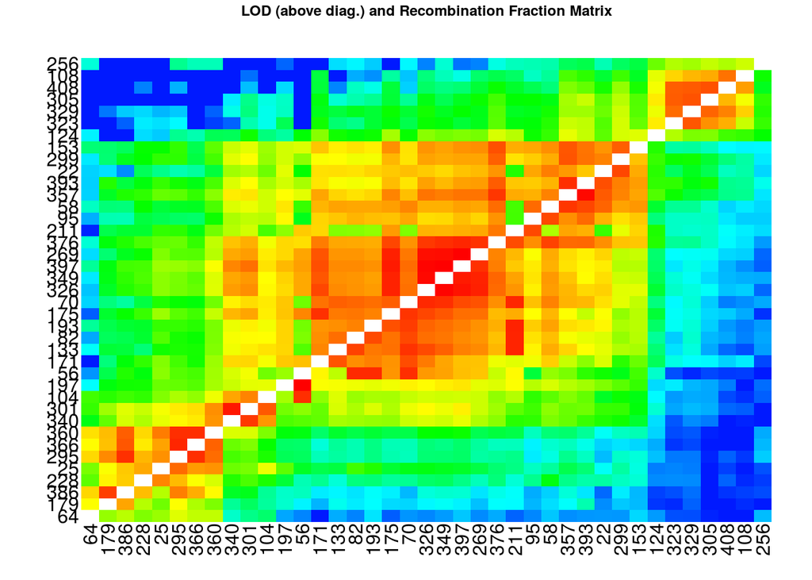

| Grupo 10 | Verossimilhança | Comprimento | N. Marcadores |
| --- | --- | --- | --- |
| Eliminando MgSTS441 | -3725.838 | 270.29 | 39 |

```r
rf.graph.table(LG10.new.fin, inter=FALSE)
```

Os marcadores CB309 e AAT283 ficaram em ordem inversa à ordem obtida no mapa de referência. Foram feitos testes para verificar a melhor ordem e igualando à ordem do mapa de referência, o grupo de ligação gerado foi de maior comprimento e com menor verossimilhança. Logo, optou-se por manter a nova ordem estabelecida com os novos marcadores.

**Grupo 12**

```r
LG12 <- make.seq(grupos, 9)
LG12
```

Neste grupo de ligação, foram agrupados 29 marcadores, sendo 13 marcadores coincidentes com os marcadores do LG12 do mapa de referência e 16 novos marcadores.

```r
LG12.ord <- order.seq(input.seq=LG12,
                        n.init = 5,
                        subset.search = "twopt",
                        twopt.alg = "rcd",
                        THRES = 3,
                        draw.try = FALSE,
                        wait = 1,
                        touchdown=TRUE)
LG12.ord

LG12.fin <- make.seq(LG12.ord, "force")
LG12.fin
```

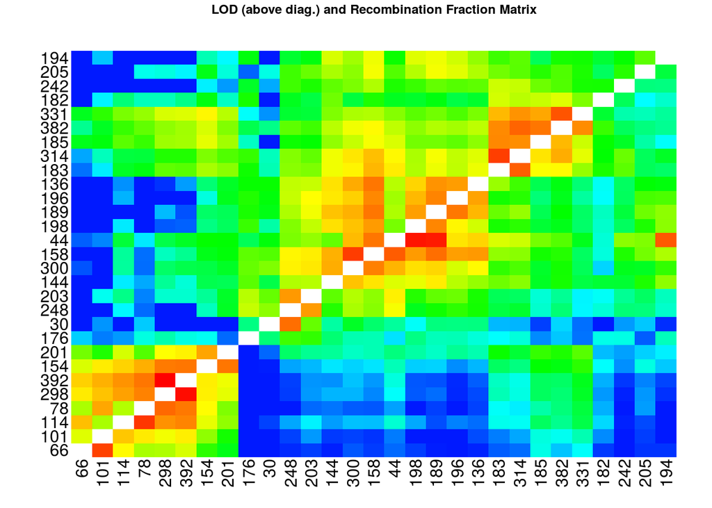

```r
rf.graph.table(LG12.fin, inter=FALSE)
```

Considerando a primeira ordem, sem trabalhar nos dados, o grupo de ligação ficaria como representado abaixo:

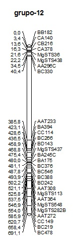

Pode-se verificar a presença de um grande gap (de 345.38 cM) entre os marcadores BC330 e AAT233. Assim, podemos visualizar a importância que é trabalhar bem os dados, retirando possíveis falso-positivos e reordenando marcadores nas melhores posições possíveis.

```r
LG12.test <- drop.marker(LG12, 194)

LG12.test.ord <- order.seq(input.seq=LG12.test,
                        n.init = 5,
                        subset.search = "twopt",
                        twopt.alg = "rcd",
                        THRES = 3,
                        draw.try = FALSE,
                        wait = 1,
                        touchdown=TRUE)

LG12.test.fin <- make.seq(LG12.test.ord, "force")
LG12.test.fin
```

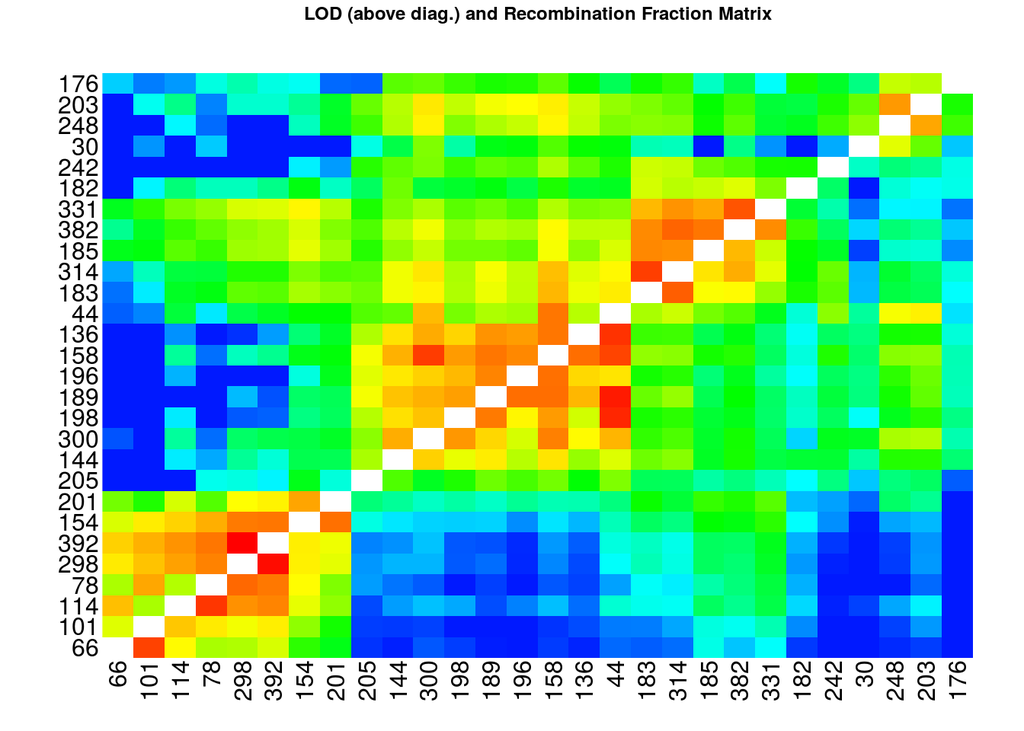

```r
rf.graph.table(LG12.test.fin, inter=FALSE)
```

Avaliando o *heatmap* para o grupo de ligação 12, foi retirado do mapa o marcador BC478. Este marcador foi facilmente verificado como falso-positivo, observando o *heatmap*. Essa retirada possibilitou obter um grupo de ligação com maior verossimilhança e menor comprimento, comparado ao grupo incluindo todos os marcadores.

| Grupo 12 | Verossimilhança | Comprimento | N. Marcadores |
| --- | --- | --- | --- |
| Todos os marcadores | -3524.141 | 691.09 | 29 |
| Menos BC478 | -3438.681 | 357.89 | 28 |

```r
ripple.seq(LG12.test.fin, ws=5, LOD=3)
```

A partir da função **ripple.seq()**, pode-se verificar uma mudança local na ordem de diversos marcadores do grupo de ligação 12.

```r
temp <- LG12.test.fin$seq.num
temp

temp[16:17] <- c(44, 136)
temp[20:22] <- c(382, 331, 185)
temp[25:28] <- c(176, 203, 248, 30)
temp

LG12.new.fin <- make.seq(freqrecomb, temp)
LG12.new.fin <- map(LG12.new.fin)
LG12.new.fin
```

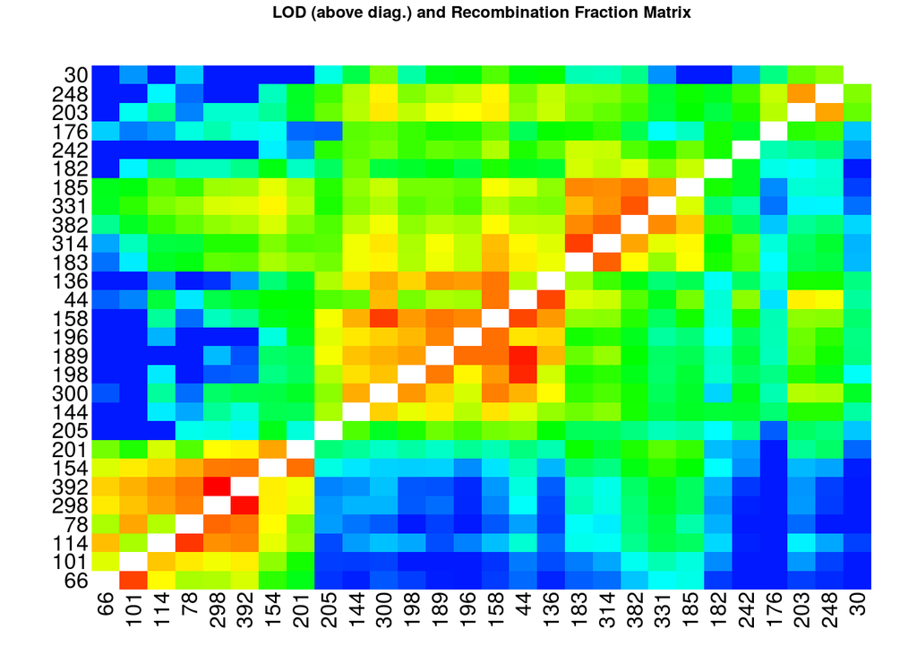

[output not shown]

```r
rf.graph.table(LG12.new.fin, inter=FALSE)
```

### 5º passo

Visualização do mapa genético parcial obtido de *Mimulus*.

```r
mapa.part <- list(LG2.new.fin, LG10.new.fin, LG12.new.fin)
```

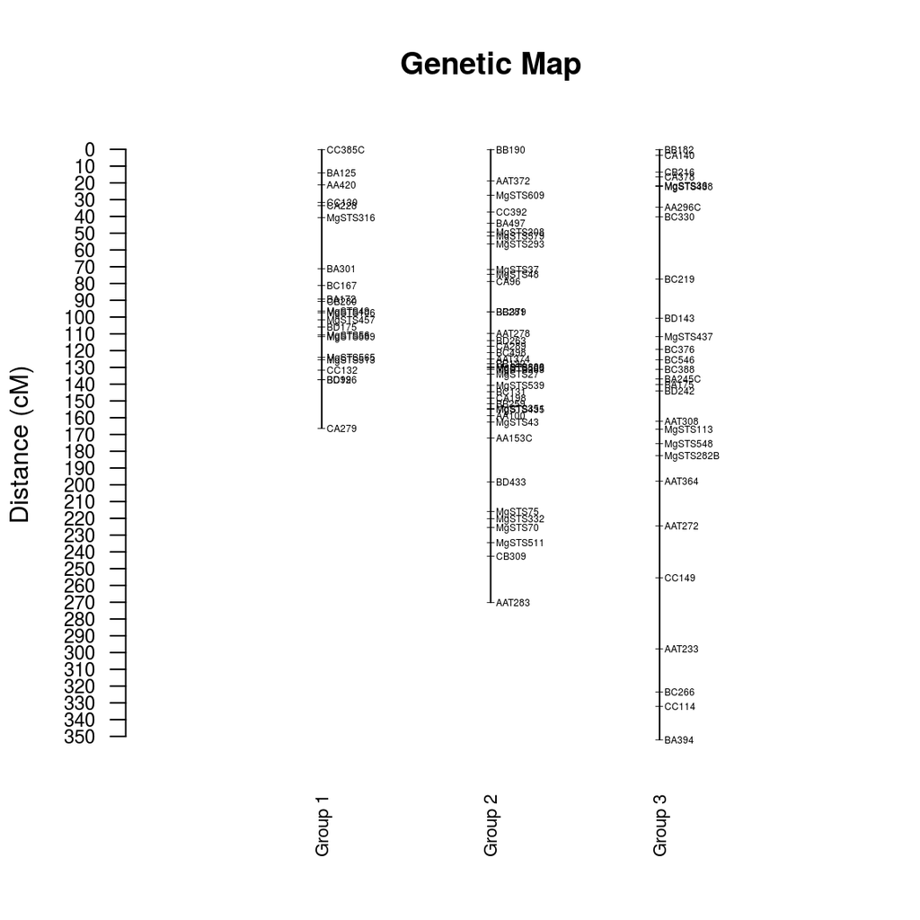

```r
draw.map(mapa.part, horizontal=FALSE, names = TRUE, grid = FALSE, cex.mrk=0.5, cex.grp=0.7)
```

```r
load("lista6.Rdata")
```

Visualização do mapa genético total obtido de *Mimulus*.

```r
mapa.tot <- list(LG1.new.fin, LG2.new.fin, LG3.new.fin, LG4.new.fin, LG5.new.fin, LG6.new.fin, LG7.new.fin,
                 LG8.new.fin, LG9.new.fin, LG10.new.fin, LG11.new.fin, LG12.new.fin, LG13.new.fin, LG14.new.fin)
```

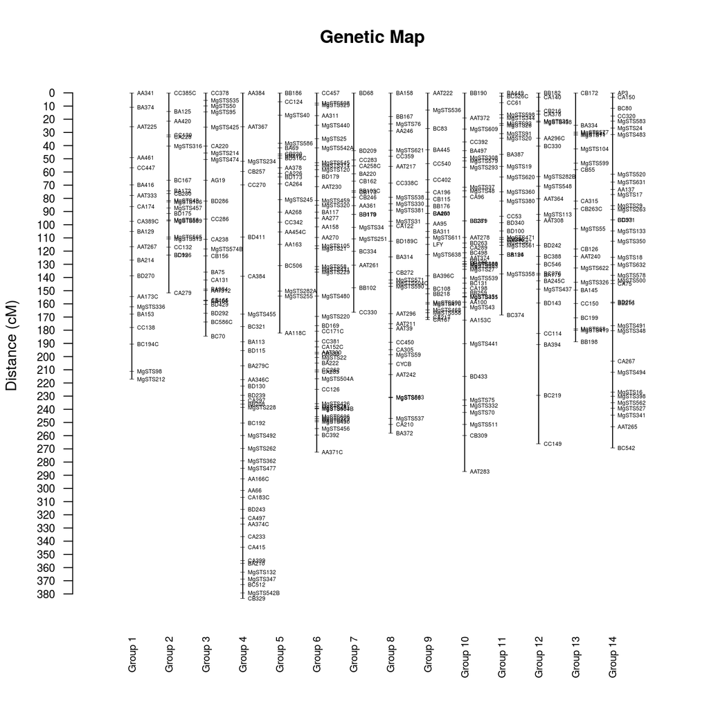

```r
draw.map(mapa.tot, horizontal=FALSE, names = TRUE, grid = FALSE, cex.mrk=0.5, cex.grp=0.7)
```

```r
save.image("Workshop.Rdata")
```

### Referências Bibliográficas

FISHMAN, L.; KELLY, A. J.; MORGAN, E.; WILLIS, J. H. A Genetic Map in the *Mimulus guttatus* Species Complex Reveals Transmission Ratio Distortion due to Heterospecific Interactions. **Genetics**, v. 159, p. 1701-1716, 2001.